# Reproducible Research: Peer Assessment 1

## Reproducible Research: Peer Assessment 1

### Loading and preprocessing the data

- Unzip database “Active Monitoring Data” and load it into the R object “db”

```r
setwd("~/RepData_PeerAssessment1")
unzip("activity.zip")
db <- read.csv("activity.csv", na.strings = "NA")
```

- Check the db structure and change class of var “date” and “interval”

```r
str(db)
```

```
## 'data.frame':    17568 obs. of  3 variables:
##  $ steps   : int  NA NA NA NA NA NA NA NA NA NA ...
##  $ date    : Factor w/ 61 levels "2012-10-01","2012-10-02",..: 1 1 1 1 1 1 1 1 1 1 ...
##  $ interval: int  0 5 10 15 20 25 30 35 40 45 ...
```

```r
db$date <- as.Date(db$date, format = "%Y-%m-%d")
db$interval <- as.factor(db$interval)
```

### What is mean total number of steps taken per day?

- Creating a histogram of the total number of steps taken each day

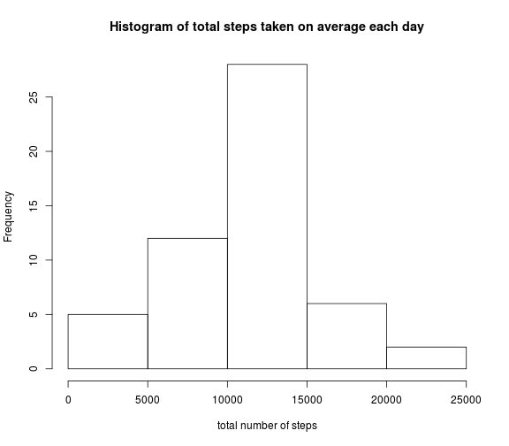

```r
a <- aggregate(db$steps, by = list(Date = db$date), FUN = "sum")
hist(a$x, main = "Histogram of total steps taken on average each day", xlab = "total number of steps")
```

- Calculate the mean and median of the total number of steps taken per day

```r
avstday <- round(mean(a$x, na.rm = T), 0); avstday
```

```
## [1] 10766
```

```r
mestday <- round(median(a$x, na.rm = T), 0); mestday
```

```
## [1] 10765
```

The **mean** of steps taken per day is **10766**

The **median** of steps taken per day is **10765**

### What is the average daily activity pattern?

- Create a plot of the number of steps accross the 5-min intervals of a day averaged accross all days

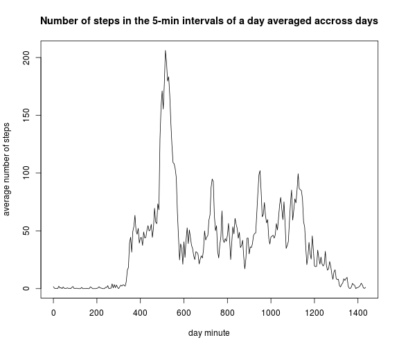

```r
b <- aggregate(steps ~ interval, FUN = "mean", data = db)
b$daymin <- as.integer(seq(0,1435,by=5))
plot(b$daymin, b$steps, type = "l", ylab = "average number of steps", xlab = "day minute", main = "Number of steps in the 5-min intervals of a day averaged accross days")
```

- Report the 5-min interval, on average across all the days in the dataset, that contains the maximum number of steps

```r
maxstepint <- b[b$steps == max(b$steps),1]; maxstepint
```

```
## [1] 835
## 288 Levels: 0 5 10 15 20 25 30 35 40 45 50 55 100 105 110 115 120 ... 2355
```

```r
maxstepmin <- b[b$steps == max(b$steps),3]; maxstepmin
```

```
## [1] 515
```

```r
maxstep <- round(max(b$steps),0); maxstep
```

```
## [1] 206
```

The interval **835** (515^ minute of the day), on average across all the days in the dataset, contains the maximum number of steps (**206**)

### Imputing missing values

- Calculate and report the total number of missing values in the dataset

```r
NAsteps <- sum(is.na(db$steps)*1); NAsteps
```

```
## [1] 2304
```

```r
NAdate <- sum(is.na(db$date)*1); NAdate
```

```
## [1] 0
```

```r
NAinterval <- sum(is.na(db$interval)*1); NAinterval
```

```
## [1] 0
```

**Missing values** of the var **“steps”** are: **2304**

**Missing values** of the var **“date”** are: **0**

**Missing values** of the var **“interval”** are: **0**

- Impute missing values of the var “steps” with the corresponding 5-min interval averaged accross all days

```r
repsteps <- rep(b$steps,61)
stepsnew = NULL
for (i in 1:17568) {
       if (is.na(db$steps[i])) {
               stepsnew[i] = round(repsteps[i],0)
       } else {
               stepsnew[i] = db$steps[i]
       }

}
db1 <- cbind(db,stepsnew)
```

- Confirm imputation process for var “steps”

```r
summary(db1$steps)
```

```
##    Min. 1st Qu.  Median    Mean 3rd Qu.    Max.    NA's
##     0.0     0.0     0.0    37.4    12.0   806.0    2304
```

```r
summary(db1$stepsnew)
```

```
##    Min. 1st Qu.  Median    Mean 3rd Qu.    Max.
##     0.0     0.0     0.0    37.4    27.0   806.0
```

```r
NAstepsimp <- sum(is.na(db1$stepsnew)*1); NAstepsimp
```

```
## [1] 0
```

The number of NA of the imputed var “stepsnew” is 0

- Make a histogram of the total number of steps taken each day with imputed dataset

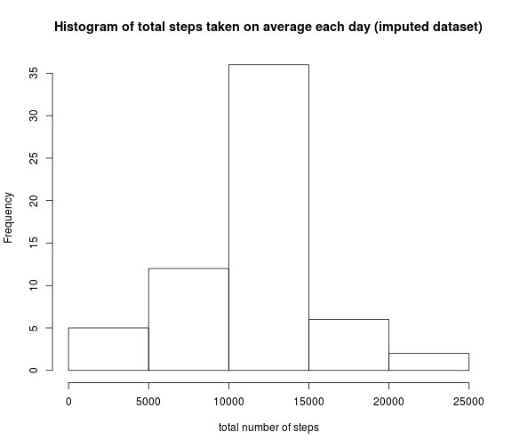

```r
c <- aggregate(db1$stepsnew, by = list(Date = db$date), FUN = "sum")
hist(c$x, main = "Histogram of total steps taken on average each day (imputed dataset)", xlab = "total number of steps")
```

- Calculate the mean and median of the total number of steps taken per day with imputed dataset

```r
avstdaynew <- format(round(mean(c$x), 0), scientif = F); avstdaynew
```

```
## [1] "10766"
```

```r
mestdaynew <- format(round(median(c$x), 0), scientif = F); mestdaynew
```

```
## [1] "10762"
```

The **mean** of steps taken per day is **10766**

The **median** of steps taken per day is **10762**

### Are there differences in activity patterns between weekdays and weekends?

- Create the factor variable “wend” to define weekday and weekend days

```r
db1$wend = NULL
for (i in 1:17568) {
       if (weekdays(db1$date[i])=="Saturday" | weekdays(db1$date[i])=="Sunday") {
        db1$wend[i] = 1
        } else {
                db1$wend[i] = 0
        }
}
db1$wend <- as.factor(db1$wend)
levels(db1$wend) <- c("weekday","weekend")
```

- Creating a panel plot containing the time series plot of the 5-min interval (x-axis) and the average number of steps taken, averaged across all weekday days or weekend days (y-axis) with the imputed dataset

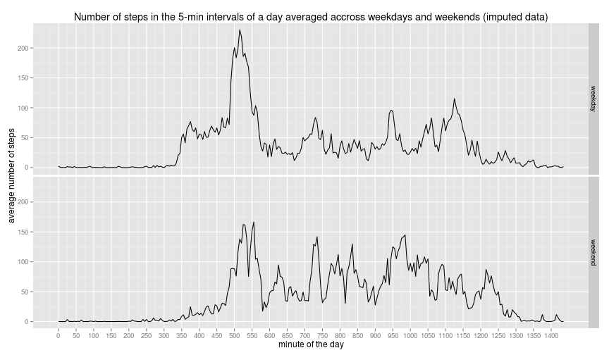

```r
library(ggplot2)
d <- aggregate(stepsnew ~ interval, FUN = "mean", data = db1[db1$wend == "weekday",])
e <- aggregate(stepsnew ~ interval, FUN = "mean", data = db1[db1$wend == "weekend",])
db2 <- rbind(d,e)
db2$wend <- factor(c(rep(0,288),rep(1,288)))
levels(db2$wend) <- c("weekday", "weekend")
db2$daymin <- as.integer(rep(seq(0,1435,by=5),2))
x <-qplot(daymin,stepsnew, data = db2, facets = wend~., geom = "line",xlab = "minute of the day", ylab = "average number of steps", main = "Number of steps in the 5-min intervals of a day averaged accross weekdays and weekends (imputed data)")
x + scale_x_continuous(breaks=seq(0,1435,by=50))
```